# Overlevelsestavler, Grønland

(opdateret den 25. juni 2024)

## Indledning

[Det konsoliderede Befolkningsregnskab](https://bank.stat.gl/pxweb/en/Greenland/Greenland__BE__BE80), opgøres for hele landet og for definerede geografiske inddelinger. Befolkningsregnskabets tabeller indeholder alle nødvendige oplysninger til at estimere befolkningens dødshyppigheder og alle afledte demografiske mål.

Da datagrundlaget således er offentligt og frit tilgængeligt, er målet med denne beskrivelse, at både beregningsmetoden og resultaterne gøres reproducerbare.

De demografiske hændelser i Befolkningsregnskabet kan fordeles efter fødselsårgang og kalenderår. Desuden anvendes i variabel, som angiver, om hændelsen sker før eller efter kalenderårets fødselsdag. Med denne viden kan hændelserne opgøres i såkaldte Lexis elementar-trekanter, som muliggør dødelighedsberegninger, hvor hændelser valgfrit kan opgøres enten ud fra:  
A) Alder og kalenderår ved hændelse eller  
B) Fødselsårgang og kalenderår ved hændelse eller  
C) Alder og fødselsårgang ved hændelse  
Når overlevelse beregnes for små befolkninger er datagrundlaget så spinkelt, at der er stor usikkerhed om de beregnede mål. Derfor beregnes overlevelse samlet for flere år. Det bemærkes at beregninger for Grønland traditionelt alene har været beregnet for 5 løbende kalenderår.

De store fødselsårgange i slutningen af 1960’erne, blev afløst af halvt så store fødselsårgange i begyndelsen af 1970’erne. Det har betydet at befolkningens aldersfordeling siden markant ændres med få års mellemrum.

5-års gennemsnit kan derfor let skjule udviklingstendenser i dødeligheden. I den kode som danner dette dokument kan køn, alder og fødested samt beregningsperiode tilpasses, men som udgangspunkt, vises her beregning af dødelighed for mænd i 67-års alderen, født i Grønland, for 5-års perioden 2019: 2023

Med dette dokument dokumenteres den anvendte beregningsmetode til dødelighed i Statistikbank-tabellen: BEDLTALL.

*En aldersbetinget dødshyppighed* angiver, hvor mange personer der dør fra én fødselsdag til den næste.

For at estimere de aldersbetingede dødshyppigheder beregnes først køns- og *aldersbetingede dødskvotienter*, som en given periodes antal dødsfald i forhold til risikobefolkningens gennemlevede tid.

Beregningsresultater gemmes i en px-fil, klar til at blive vist i Statistikbanken eller lokalt med Pxwin. Se [den svenske Statistikmyndighed SCB](https://www.scb.se/en/services/statistical-programs-for-px-files/px-web/) for mere information.

PX-filen dannes med R-pakken pxmake. Se github.com/StatisticsGreenland/pxmake for mere info & kilde kode.

## Anbefalet beregningsmetode

For at være retvisende skal dødelighed for små befolkninger beregnes for flere år og estimeres ved b-grupper.

Nedenfor er detaljerede beregninger gennemgået for beregninger for hhv a-, b-grupper og c-grupper(for 0-årige).

Beregnet for et kalenderår består en a-gruppe af personer, med forskellig fødselsårgang. Dermed opstår en relativ stor korrektionspost i Befolkningsregnskabet.

Når beregningerne i stedet baseres på b-grupper (fødselårgang i samme kalenderår) går korrektionsposten over en årrække mod 0.

### (A) Alder & kalenderår, Lexis firkanter (a-grupper)

Lexis firkanter (alder ved død og kalenderår) er den mindst datakrævende beregningsmetode og metoden som ofte anvendes ved beregninger for større befolkninger.

Dødskvotienten beregnes som (døde i alder x)/(middelfolketal i alder x) for den samme tidsperiode.

Fra den almindelige befolkningsstatistik genfindes disse tal:

[Alder 67 i begyndelsen af året](https://bank.stat.gl:443/sq/89907574-0c83-4996-95e2-4608d32a5d99)  
[Alder 67 i slutningen af året=Alder 68 i begyndelsen af det efterfølgende år](https://bank.stat.gl:443/sq/2e397143-5e82-4d59-88cc-07abc986b518)

**Figur 2 Lexis firkanter, Case: mænd, født i Grønland (2019 - 2023)**

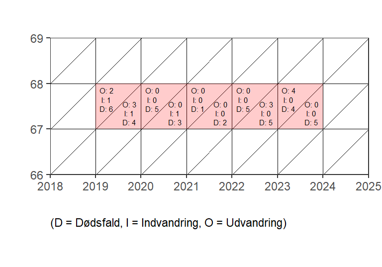

**Tabel 1. Sum (rødt areal) - alder: 67, fødselsårgang: 1951 - 1956**

Fødested: Grønland

|  | Døde | Indvandring | Udvandring | Befolkning (primo) | Befolkning (ultimo) | Middelfolketal | Korrektioner |
| --- | --- | --- | --- | --- | --- | --- | --- |
| Total | 40 | 3 | 12 | 1,052 | 979 | 1,015.5 | −24 |
| 2019 | 10 | 2 | 5 | 194 | 198 | 196.0 | 17 |
| 2020 | 8 | 1 | 0 | 202 | 182 | 192.0 | −13 |
| 2021 | 3 | 0 | 0 | 192 | 191 | 191.5 | 2 |
| 2022 | 10 | 0 | 3 | 223 | 189 | 206.0 | −21 |
| 2023 | 9 | 0 | 4 | 241 | 219 | 230.0 | −9 |

**Dødshyppighed** (alder: 67 ) = 40 / 1015.5 **= 0.0393895**

**Udvandringshyppighed** (alder: 67 ) = 12 / 1015.5 **= 0.0118168**

### (B) Fødselsårgang og kalenderår, Lexis vertikale parallelogrammer (b-grupper)

Med Lexis vertikale parallelogrammer beregnes dødshyppigheder fra samme fødselsårgang, indefor et kalenderår, som så strækker sig over 2 aldre. Korrektionsposten er her tilnærmelsesvis lig nul, og vil primært skyldes forskinkede indberetninger fra til det administrative befolkningsregister, som udjævnes over tid.  
Dødskvotienterne beregnes som summen af døde delt med summen af middelfolketallet Dødshyppigheden for alder x beregnes som gennemsnittet af 2 dødskvotienter som (dødskvotient i fødselsårgang x + dødskvotient i fødselsårgang x+1) for det samme tids span.

**Figur 3 Lexis, vertikale parallelogrammer, Case: mænd, født i Grønland (2019 - 2023)**

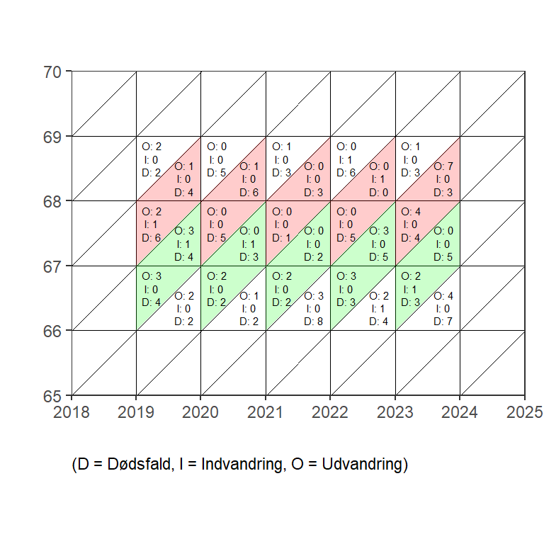

**Tabel 2a. B1 (rødt areal) - Alder: 67/68, Fødselsårgang: 1951 - 1955**

Fødested: Grønland

| period | Døde | Indvandring | Udvandring | Befolkning (primo) | Befolkning (ultimo) | Middelfolketal | Korrektioner |
| --- | --- | --- | --- | --- | --- | --- | --- |
| Total | 37 | 2 | 15 | 1,052 | 1,003 | 1,027.5 | 1 |
| 2019 | 10 | 1 | 3 | 194 | 182 | 188.0 | 0 |
| 2020 | 11 | 0 | 1 | 202 | 191 | 196.5 | 1 |
| 2021 | 4 | 0 | 0 | 192 | 189 | 190.5 | 1 |
| 2022 | 5 | 1 | 0 | 223 | 219 | 221.0 | 0 |
| 2023 | 7 | 0 | 11 | 241 | 222 | 231.5 | −1 |

**Tabel 2b. B2 (grønt areal) - Alder: 66/67, Fødselsårgang: 1952 - 1956**

Fødested: Grønland

| period | Døde | Indvandring | Udvandring | Befolkning (primo) | Befolkning (ultimo) | Middelfolketal | Korrektioner |
| --- | --- | --- | --- | --- | --- | --- | --- |
| Total | 33 | 3 | 18 | 1,159 | 1,111 | 1,135.0 | 0 |
| 2019 | 8 | 1 | 6 | 215 | 202 | 208.5 | 0 |
| 2020 | 5 | 1 | 2 | 199 | 192 | 195.5 | −1 |
| 2021 | 4 | 0 | 2 | 229 | 223 | 226.0 | 0 |
| 2022 | 8 | 0 | 6 | 254 | 241 | 247.5 | 1 |
| 2023 | 8 | 1 | 2 | 262 | 253 | 257.5 | 0 |

**Tabel 2c. Dødskvotienter (Dødsfald/Middelfolketal) beregnet fra totaler i B1 & B2**

| src | Døde | Befolkning (primo) | Befolkning (ultimo) | Middelfolketal | Deathrate |
| --- | --- | --- | --- | --- | --- |
| B1 | 37 | 1,052 | 1,003 | 1,027.5 | 0.0360 |
| B2 | 33 | 1,159 | 1,111 | 1,135.0 | 0.0291 |

**Tabel 2d. Udvandringskvotient (Udvandring/Middelfolketal) beregnet fra totaler i B1 & B2**

| src | Udvandring | Befolkning (primo) | Befolkning (ultimo) | Middelfolketal | Emigrationrate |
| --- | --- | --- | --- | --- | --- |
| B1 | 15 | 1,052 | 1,003 | 1,027.5 | 0.0146 |
| B2 | 18 | 1,159 | 1,111 | 1,135.0 | 0.0159 |

**Dødshyppighed** (alder: 67 ) = sum(0.0360097, 0.0290749) / 2 **= 0.0325423**

**Udvandringshyppighed** (alder: 67 ) = sum(0.0145985, 0.015859) / 2 **= 0.0152288**

### (C) Fødselsårgang, første leveår. Lexis horisontale parallelogrammer

I første leveår beregnes døds- og udvandringshyppighederne direkte fra fødsel til alder 1 år, som gennemsnit for 1 eller flere fødselsårgange.

**Figur 4 Lexis, horisontale parallelogrammer, Case: mænd, født i Grønland (2019 - 2023)**

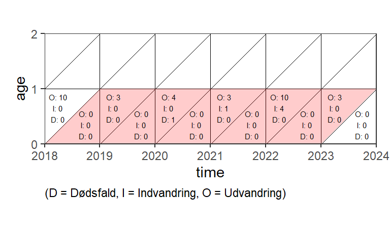

Tabel 3. Beregning af død- og udvandringshyppighed for 0-årige (5 år)

| cohort | Dødsfald | Udvandrede | Levendefødte | Dødshyppighed | Udvandringshyppighed |
| --- | --- | --- | --- | --- | --- |
| Total | 6 | 140 | 1849 | 0.0032 | 0.0757 |
| 2018 | 1 | 42 | 399 | 0.0025 | 0.1053 |
| 2019 | 2 | 30 | 395 | 0.0051 | 0.0759 |
| 2020 | 0 | 33 | 384 | 0.0000 | 0.0859 |
| 2021 | 1 | 25 | 325 | 0.0031 | 0.0769 |
| 2022 | 2 | 10 | 346 | 0.0058 | 0.0289 |

## Dødelighed

**Figur 5 Dødelighed efter køn, Case: mænd, født i Grønland (2019 - 2023)**

5-års beregningsgrundlag

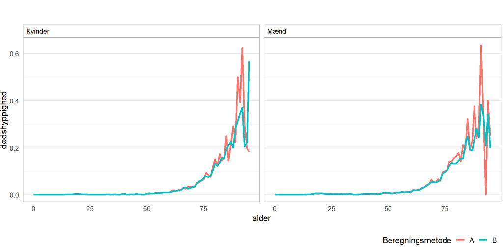

### Dødshyppigheder

**Tabel 4: Dødshyppigheder beregnet som a- og b-grupper. 2019 - 2023**

| age | Total A I alt | Total A Kvinder | Total A Mænd | Total B I alt | Total B Kvinder | Total B Mænd | Født i Grønland A I alt | Født i Grønland A Kvinder | Født i Grønland A Mænd | Født i Grønland B I alt | Født i Grønland B Kvinder | Født i Grønland B Mænd |
| --- | --- | --- | --- | --- | --- | --- | --- | --- | --- | --- | --- | --- |
| 0 | 0.0002 | 0.0000 | 0.0005 | 0.0030 | 0.0030 | 0.0030 | 0.0003 | 0.0000 | 0.0005 | 0.0033 | 0.0033 | 0.0032 |
| 1 | 0.0022 | 0.0020 | 0.0024 | 0.0014 | 0.0013 | 0.0015 | 0.0023 | 0.0021 | 0.0025 | 0.0014 | 0.0013 | 0.0015 |
| 2 | 0.0005 | 0.0005 | 0.0005 | 0.0006 | 0.0002 | 0.0010 | 0.0005 | 0.0005 | 0.0005 | 0.0006 | 0.0003 | 0.0010 |
| 3 | 0.0007 | 0.0005 | 0.0010 | 0.0005 | 0.0003 | 0.0007 | 0.0008 | 0.0005 | 0.0010 | 0.0005 | 0.0003 | 0.0007 |
| 4 | 0.0000 | 0.0000 | 0.0000 | 0.0001 | 0.0003 | 0.0000 | 0.0000 | 0.0000 | 0.0000 | 0.0001 | 0.0003 | 0.0000 |
| 5 | 0.0003 | 0.0005 | 0.0000 | 0.0003 | 0.0003 | 0.0002 | 0.0003 | 0.0006 | 0.0000 | 0.0003 | 0.0003 | 0.0003 |
| 6 | 0.0003 | 0.0000 | 0.0005 | 0.0004 | 0.0003 | 0.0005 | 0.0003 | 0.0000 | 0.0005 | 0.0004 | 0.0003 | 0.0005 |
| 7 | 0.0003 | 0.0000 | 0.0005 | 0.0001 | 0.0000 | 0.0002 | 0.0003 | 0.0000 | 0.0005 | 0.0001 | 0.0000 | 0.0003 |
| 8 | 0.0003 | 0.0000 | 0.0005 | 0.0001 | 0.0000 | 0.0003 | 0.0003 | 0.0000 | 0.0005 | 0.0001 | 0.0000 | 0.0003 |
| 9 | 0.0003 | 0.0005 | 0.0000 | 0.0003 | 0.0003 | 0.0003 | 0.0003 | 0.0006 | 0.0000 | 0.0003 | 0.0003 | 0.0003 |
| 10 | 0.0003 | 0.0000 | 0.0005 | 0.0003 | 0.0003 | 0.0003 | 0.0003 | 0.0000 | 0.0005 | 0.0003 | 0.0003 | 0.0003 |
| 11 | 0.0000 | 0.0000 | 0.0000 | 0.0003 | 0.0003 | 0.0003 | 0.0000 | 0.0000 | 0.0000 | 0.0003 | 0.0003 | 0.0003 |
| 12 | 0.0003 | 0.0005 | 0.0000 | 0.0003 | 0.0005 | 0.0000 | 0.0003 | 0.0006 | 0.0000 | 0.0003 | 0.0006 | 0.0000 |
| 13 | 0.0008 | 0.0006 | 0.0010 | 0.0005 | 0.0005 | 0.0005 | 0.0008 | 0.0006 | 0.0011 | 0.0006 | 0.0006 | 0.0005 |
| 14 | 0.0014 | 0.0011 | 0.0016 | 0.0011 | 0.0008 | 0.0013 | 0.0014 | 0.0012 | 0.0017 | 0.0011 | 0.0009 | 0.0014 |
| 15 | 0.0021 | 0.0018 | 0.0023 | 0.0020 | 0.0015 | 0.0026 | 0.0019 | 0.0019 | 0.0018 | 0.0020 | 0.0016 | 0.0024 |
| 16 | 0.0021 | 0.0012 | 0.0029 | 0.0021 | 0.0012 | 0.0029 | 0.0022 | 0.0013 | 0.0031 | 0.0021 | 0.0013 | 0.0028 |
| 17 | 0.0019 | 0.0011 | 0.0027 | 0.0024 | 0.0017 | 0.0031 | 0.0020 | 0.0012 | 0.0028 | 0.0025 | 0.0018 | 0.0032 |
| 18 | 0.0041 | 0.0027 | 0.0054 | 0.0037 | 0.0025 | 0.0048 | 0.0040 | 0.0023 | 0.0056 | 0.0037 | 0.0023 | 0.0050 |
| 19 | 0.0032 | 0.0027 | 0.0037 | 0.0036 | 0.0025 | 0.0048 | 0.0034 | 0.0028 | 0.0039 | 0.0037 | 0.0023 | 0.0050 |
| 20 | 0.0039 | 0.0032 | 0.0047 | 0.0043 | 0.0032 | 0.0053 | 0.0041 | 0.0033 | 0.0049 | 0.0045 | 0.0034 | 0.0056 |
| 21 | 0.0049 | 0.0026 | 0.0071 | 0.0046 | 0.0027 | 0.0065 | 0.0052 | 0.0028 | 0.0076 | 0.0049 | 0.0028 | 0.0069 |
| 22 | 0.0030 | 0.0015 | 0.0044 | 0.0032 | 0.0016 | 0.0048 | 0.0032 | 0.0016 | 0.0048 | 0.0035 | 0.0017 | 0.0052 |
| 23 | 0.0029 | 0.0025 | 0.0033 | 0.0024 | 0.0020 | 0.0027 | 0.0031 | 0.0026 | 0.0036 | 0.0026 | 0.0022 | 0.0030 |
| 24 | 0.0021 | 0.0014 | 0.0027 | 0.0022 | 0.0020 | 0.0024 | 0.0023 | 0.0016 | 0.0030 | 0.0024 | 0.0021 | 0.0026 |
| 25 | 0.0009 | 0.0005 | 0.0013 | 0.0022 | 0.0012 | 0.0032 | 0.0010 | 0.0005 | 0.0015 | 0.0024 | 0.0013 | 0.0035 |
| 26 | 0.0029 | 0.0013 | 0.0043 | 0.0020 | 0.0009 | 0.0031 | 0.0032 | 0.0015 | 0.0048 | 0.0023 | 0.0010 | 0.0034 |
| 27 | 0.0011 | 0.0004 | 0.0017 | 0.0014 | 0.0005 | 0.0024 | 0.0012 | 0.0005 | 0.0019 | 0.0016 | 0.0005 | 0.0027 |
| 28 | 0.0019 | 0.0008 | 0.0028 | 0.0016 | 0.0009 | 0.0023 | 0.0022 | 0.0010 | 0.0033 | 0.0018 | 0.0010 | 0.0026 |
| 29 | 0.0010 | 0.0008 | 0.0012 | 0.0015 | 0.0011 | 0.0020 | 0.0012 | 0.0010 | 0.0014 | 0.0018 | 0.0012 | 0.0024 |

[output cut: 65 more lines]

## Statistikbank tabel

Endelig skal hyppighedstabeller suppleres med metadata for at kunne præsenteres i Statistikbanken.

Dette gøres med Grønlands Statistiks r-pakke ‘pxmake’, som findes på Github

```r
# Convert the dataframe px_data_lt a px-file, ready to use

# devtools::install_github("StatisticsGreenland/pxmake")
library(pxmake)

lastupdated    <- "20240701 09:00" # release date
nextupdate     <- "20250308 09:00" # next release date

# get metadata into px-object (z), from previous px-file: BEXLTALL.px
z <- pxmake::px(file.path(previousPath,"BEXLTALL.px")) %>%
# + update date for : last updated and next update
  px_last_updated(format(lastupdated,format='%Y%m%d %H:%M')) %>%
  px_next_update(format(nextupdate,format='%Y%m%d %H:%M')) %>%
# + update description and title
  px_description(data.frame(language = c("en", "da", "kl"),
    value = c(paste0("Life Tables ",(CONST_start_year+5)," - ",
             CONST_end_event_year," <em>[BEELTALL]</em>"),
             paste0("Overlevelsestavler ",(CONST_start_year+5),
              " - ",CONST_end_event_year," <em>[BEDLTALL]</em>"),
             paste0((CONST_start_year+5)," - ",CONST_end_event_year,
              ", Agguaqatigiissillugu ukioqqortussuseq <em>[BENLTALL]</em>")))) %>%
  px_title(data.frame(language = c("en", "da", "kl"),
                   value = c("Life Tables ",
                             "Overlevelsestavler ",
                             "Agguaqatigiissillugu ukioqqortussuseq"))) %>%
  px_infofile("beregningsmetode") %>%
  px_note(tibble::tribble(~language, ~value,
                          "en", "Read ",
                          "da", "Læs mere om beregningsmetode ",
                          "kl", "Læs mere om beregningsmetode",
                          ))


# create px-object from px_data_lt
x <- pxmake::px(px_data_lt %>% rename(figures_=value))

# replace data in z with data from x
z$data <- x$data

# save px-object to file, overwriting if it already exists
px_save(z, file.path(resultsPath,"BEXLTALL_tmp.px"))

px_save(z, file.path(resultsPath,"BEXLTALL_tmp.xlsx"), save_data=FALSE)

#add Greenlandic translations
y <- pxmake::px(file.path(resultsPath,"BEXLTALL_bova.xlsx"))

y$data <- x$data

y <- y %>% px_notex(NULL)

px_save(y, file.path(resultsPath,"BEXLTALL.px"))
```